## Ashley Mersman

2/10/2023

# Task 3 - Titanic (from 9.12 above)

Follow the instructions in 9.12.3 (starting pg. 346). Don't work in interactive mode!

Instead complete the exercise in a notebook.

1-Load: Use pandas to read in the Titanic Disaster dataset csv file.

2-View: Set the precision to 2 decimal places. View the head and tail of the file.

3-Headings: customize the column headings.

4-Describe: Use the DataFrame describe() function to calculate basic descriptive statistics for all numeric columns. 5-Survivors: Follow instructions to describe statistics for those who survived (titanic.survived == 'yes') - see the example. Notice that describe provides different results for non-numeric data (e.g., unique, top, freq) Enable matplotlib. If it doesn't work (e.g., in a notebook), try %matplotlib inline 6-Histogram: Use the DataFrame's hist() function to create a histogram for each numerical column. Required: Use Section headings in your Markdown to make it clear that each of these 6 sections are shown in your notebook. They should be numbered 1-6 and include the keyword shown above. Required: Include the title of the notebook, and your name and date at the top. Do these consistently. A heading and section titles is required in every notebook.

## 1. import modules and load dataset into pandas

```python
import pandas as pd
df = pd.read_csv('https://vincentarelbundock.github.io/' + 'Rdatasets/csv/carData/TitanicSurvival.csv')
```

## 2. set precision to 2 decimal places and view the head and tail of the database

```python
pd.set_option('precision', 2)
df.head()
```

|  | Unnamed: 0 | survived | sex | age | passengerClass |
| --- | --- | --- | --- | --- | --- |
| 0 | Allen, Miss. Elisabeth Walton | yes | female | 29.00 | 1st |
| 1 | Allison, Master. Hudson Trevor | yes | male | 0.92 | 1st |
| 2 | Allison, Miss. Helen Loraine | no | female | 2.00 | 1st |
| 3 | Allison, Mr. Hudson Joshua Crei | no | male | 30.00 | 1st |
| 4 | Allison, Mrs. Hudson J C (Bessi | no | female | 25.00 | 1st |

```python
df.tail()
```

|  | Unnamed: 0 | survived | sex | age | passengerClass |
| --- | --- | --- | --- | --- | --- |
| 1304 | Zabour, Miss. Hileni | no | female | 14.5 | 3rd |
| 1305 | Zabour, Miss. Thamine | no | female | NaN | 3rd |
| 1306 | Zakarian, Mr. Mapriededer | no | male | 26.5 | 3rd |
| 1307 | Zakarian, Mr. Ortin | no | male | 27.0 | 3rd |
| 1308 | Zimmerman, Mr. Leo | no | male | 29.0 | 3rd |

## 3. Headings: customize the column headings.

```python
df.columns = ['name', 'survived', 'sex', 'age', 'class']
df.head()
```

|  | name | survived | sex | age | class |
| --- | --- | --- | --- | --- | --- |
| 0 | Allen, Miss. Elisabeth Walton | yes | female | 29.00 | 1st |
| 1 | Allison, Master. Hudson Trevor | yes | male | 0.92 | 1st |
| 2 | Allison, Miss. Helen Loraine | no | female | 2.00 | 1st |
| 3 | Allison, Mr. Hudson Joshua Crei | no | male | 30.00 | 1st |
| 4 | Allison, Mrs. Hudson J C (Bessi | no | female | 25.00 | 1st |

## 4. Describe: Use the DataFrame describe() function to calculate basic descriptive statistics for all numeric columns.

```python
df.describe()
```

|  | age |
| --- | --- |
| count | 1046.00 |
| mean | 29.88 |
| std | 14.41 |
| min | 0.17 |
| 25% | 21.00 |
| 50% | 28.00 |
| 75% | 39.00 |
| max | 80.00 |

```python
(df.survived == 'yes').describe()
```

```
count      1309
unique        2
top       False
freq        809
Name: survived, dtype: object
```

## 6. Histogram: Use the DataFrame's hist() function to create a histogram for each numerical column.

```
array([[<AxesSubplot:title={'center':'age'}>]], dtype=object)
```

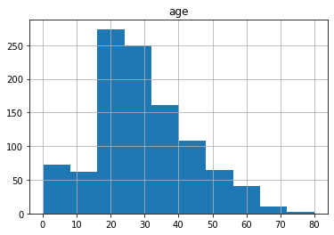

```python
df.hist()
```